# GGPLOT: BAR CHARTS

# 3.2: DODGED BARCHART

Sometimes a stacked barchart may not be easy to understand or interpret. Well, there is a solution to that: Dodged Barcharts!

Dodged barcharts are very similar to stacked barcharts, with very minor changes in code syntax. We will look at grouped barcharts with our previous example of alcohol consumption.

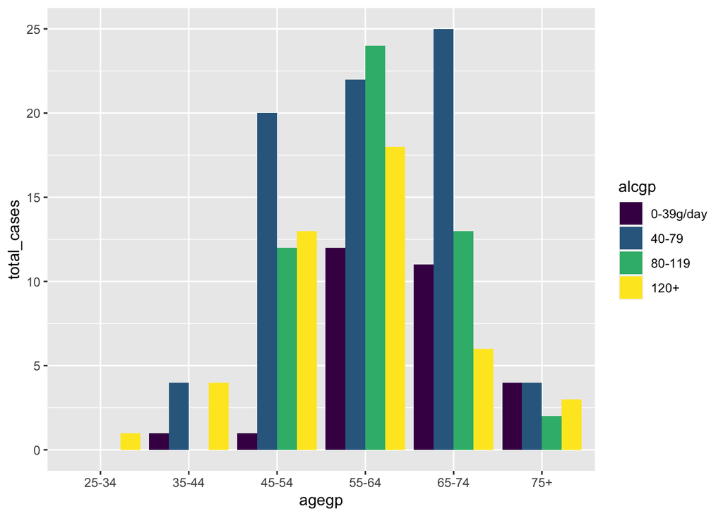

```r
dodged_bc <- ggplot(alc_cases, aes(x = agegp, y = total_cases, fill = alcgp)) +
  geom_bar(stat = "identity",
           position = "dodge")  # Need to specify position = "dodge" to group bars next to each other
dodged_bc
```

## 3.2.1: COLOR (Redundant Maybe Delete? Move somewhere else?)

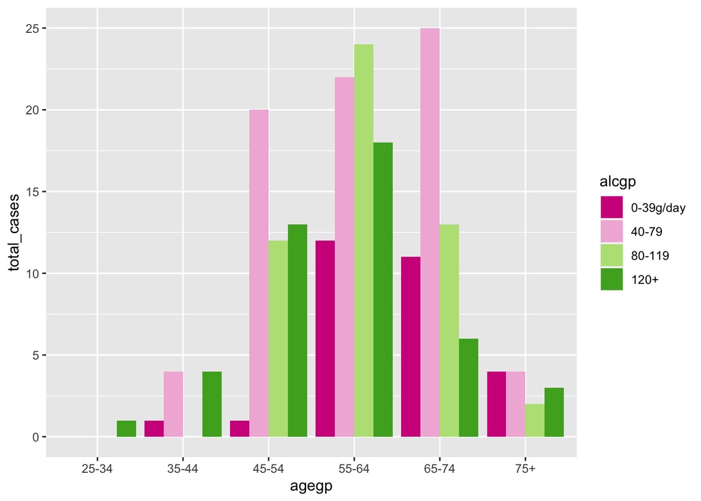

```r
# Change color the same way you did for stacked barcharts
# with either scale_fill_manual or scale_fill_brewer

dodged_bc + scale_fill_brewer(palette = "PiYG")
```

## 3.2.2: LABELS (Redundant Maybe Delete? Move somewhere else?)

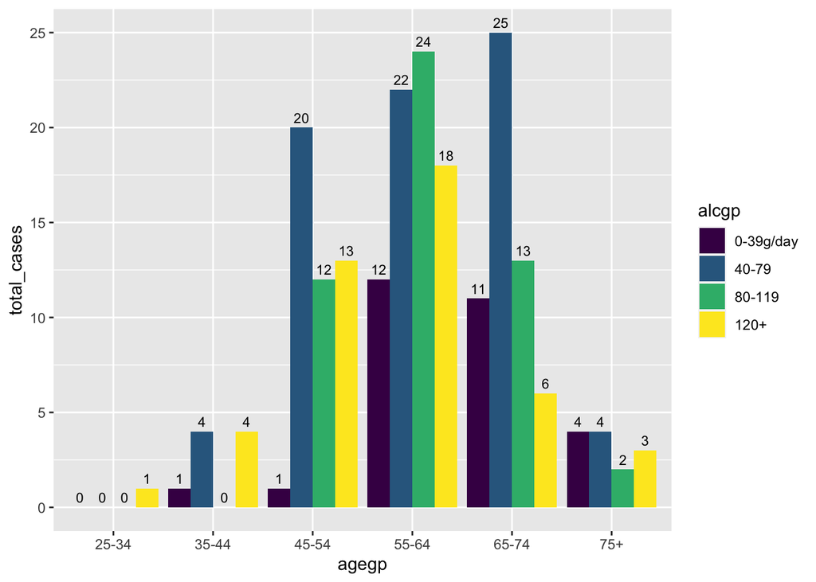

```r
# If you would like to include the empty bar space along with the values
dodged_bc +
  geom_text(aes(label = total_cases), position = position_dodge(0.9),
            vjust = -0.5, size = 3, color = "black")
```

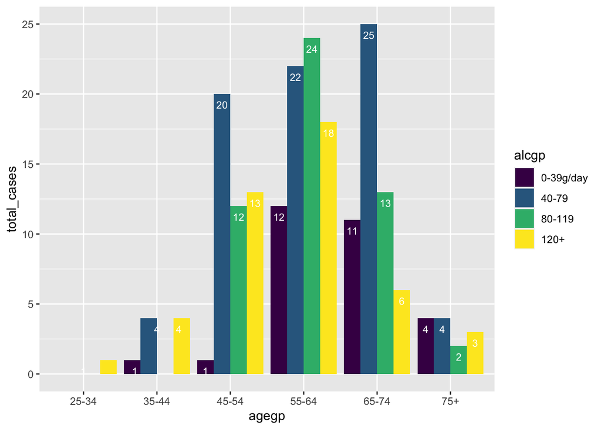

```r
# If you do not want values of 0 to show up on the graph
dodged_bc +
  geom_text(data=subset(alc_cases, total_cases != 0),
            aes(label = total_cases), position = position_dodge(0.9),
            vjust = 2, size = 3, color = "#ffffff")
```

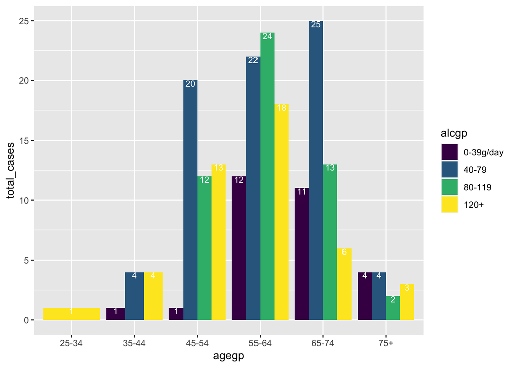

```r
# Notice that this graph above shows the empty bar space that we don't want and
# therefore some of the numbers are not formatted on the bar.
# To fix this, we need to remove any rows where the total_cases is 0
# from our dataset and plot again

alc_cases2 <- alc_cases %>%
  filter(total_cases > 0)

ggplot(alc_cases2, aes(x = agegp, y = total_cases, fill = alcgp)) +
  geom_bar(stat = "identity", position = "dodge") +
  geom_text(aes(label = total_cases), position = position_dodge(0.9),
            vjust = 1, size = 3, color = "#ffffff") # Much better!
```

The code for everything else for dodged barcharts is similar to what has been previously covered in this module.

TRY-IT-YOURSELF: You have already created a stacked barchart for tobacco consumption. Similarly, now that we have gone through grouped barcharts, produce a professional grouped barchart that shows the number of cases of esophageal cancer by each age group’s tobacco consumption.

```r
#Type your answer here
```

## 3.3: FACETED BAR CHARTS (Find different data to demonstrate this)

## 3.4: HORIZONTAL BAR CHART

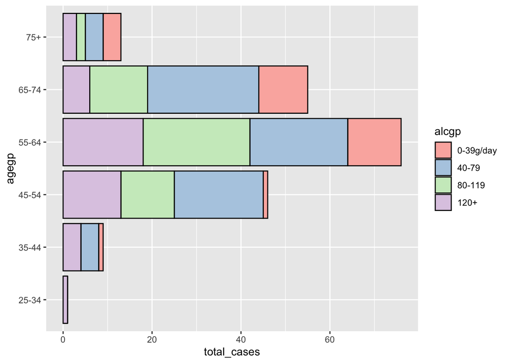

```r
# Flipping the axis of the barchart
barchart3 +
  coord_flip() # Mention this to swap the x and y axes
```

## (MOVE THIS AND WORK ON EVERYTHING BEYOND HERE)

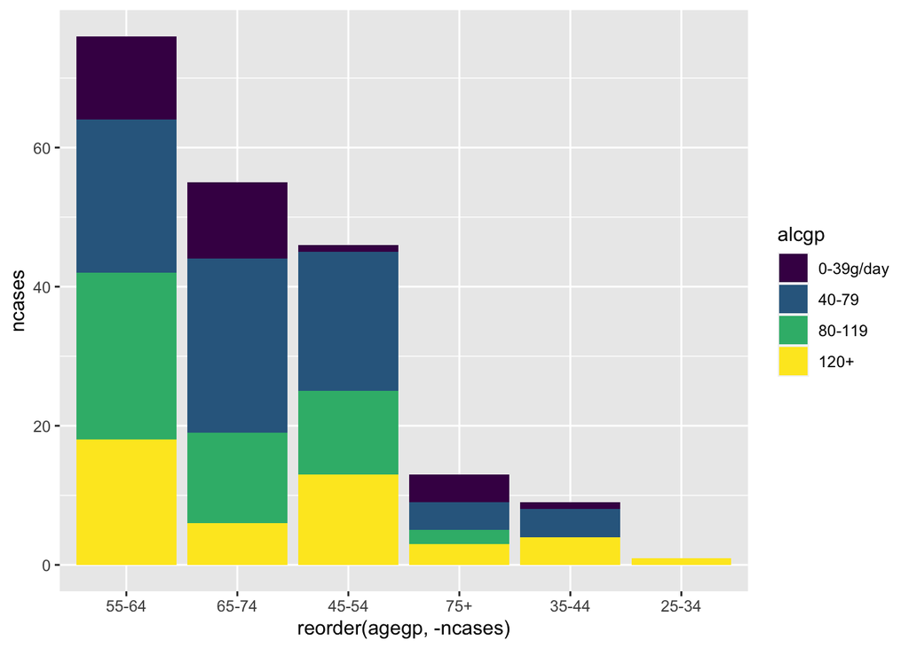

```r
# Reordering the bars in ascending/descending order
ggplot(esoph,aes(x = reorder(agegp,-ncases), y = ncases, fill = alcgp)) +
  geom_bar(stat ="identity")
```

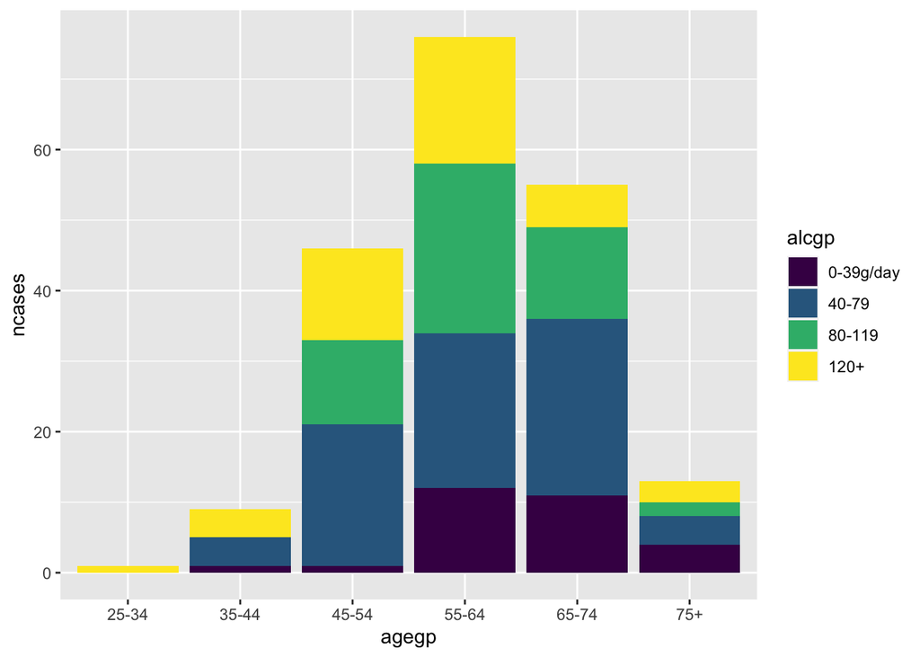

```r
# Syntax: x = reorder(X variable,+/-Y variable); + = ascending, - = descending
# NOTE: It does not make sense to reorder the bars in this context
# as the age group categories are out of order

# Reverse the stacking of the bars
ggplot(esoph,aes(x = agegp, y = ncases, fill = alcgp)) +
  geom_bar(stat ="identity", position = position_stack(reverse = TRUE))
```

TRY-IT-YOURSELF: Now that we have reviewed stacked barcharts, it’s time for you to create and modify one! Produce a professional stacked barchart that shows the number of cases of esophageal cancer by each age group’s tobacco consumption.

```r
# Type your answer here
```

SUMMARY/RECAP:

- We have reviewed how to customize ggplots for publications or presentation to a professional audience
- We explored modifications to color, labels, appearance, and legends
- You should be able to produce a polished barchart that is publication-worthy (run the code below for a professional barchart)

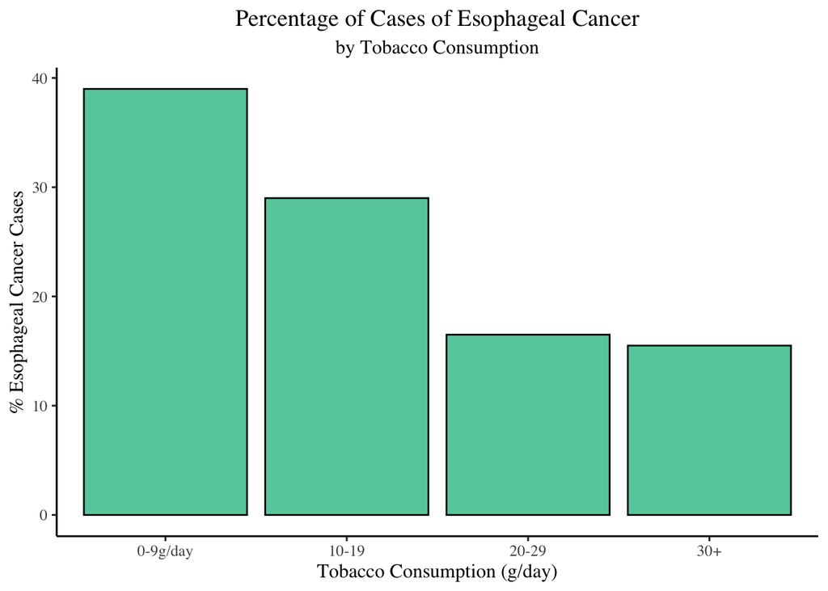